# Animal Resource Selection, Day 2

Peter Mahoney and Michel Kohl, Utah State University

March 2016

# Model validation using Leave-one-out (LOO) Cross-Validation

Model validation is difficult in general, let alone in a mixed model context. The best way to evaluate model performance is through the use *out-of-sample* validation, or by fitting a model to new data. However, this not feasible in most situations. The best alternative is to use an *in-sample* validation procedure by iteratively refitting models to subsets of the data (*e.g.* using *K-folds* or *LOO*), whereby the model uses a portion of the data to *train* the model and remaining data to *test* the model *fit*.

The *K-folds* procedure articulated in Boyce *etal.* (2002) is generally overly optimistic in that it doesn’t take into conderation the random effects or heirarchical levels of the model. The subsets should either sample proportionally across all individuals or by removing an individual one-by-one.

Here, we will show you how to implement LOO in a frequentist context using code authored by ourselves and Mark Hebblewhite.

```r
# Load the necessary libraries
library(lme4)

# Source LOO script
source('./Source/LOO.R')

# Load the data
d <- read.csv("./Data/RSFdata_std_rand10x.csv")
```

Currently, you will need to specify the formula’s for both the mixed and standard GLM. Both model formulas should be the same with the exception of the inclusion of the a single random effect in the former.

```r
# Define the formulas to validate
formMix <- 'Used ~ slope + elev +
  dist_dlv + dist_lbv + dist_blv +
  dist_paved + dist_unpaved +
  dist_rivers +
  Dry:dist_rivers +
  NDVI +
  (1|ID)'

formNonMix <- 'Used ~ slope + elev +
  dist_dlv + dist_lbv + dist_blv +
  dist_paved + dist_unpaved +
  dist_rivers +
  Dry:dist_rivers +
  NDVI'
```

The `loo` function performs the *leave-one-out* operation by cycling through and pulling one individual out, fitting a model, and comparing model fit with the data from a single individual.

```r
# Run the LOO cross-validation based
# on model specifications
out <- loo(d, formMix, formNonMix, thin=1,
           rE = 'ID')
```

To table *precision*, *bias*, and *correlation* metrics.

```r
# Table output from LOO run
(tab <- tableLOO(out))
```

[output not shown]

```r
# Mean correlation in LOO
knitr::kable(tab <- tableLOO(out))
```

|  | Precision | Bias | Correlation |
| --- | --- | --- | --- |
| Queen | 7.02e-05 | 0 | -0.0162480 |
| Gabs | 2.02e-05 | 0 | 0.3709919 |
| Cilla | 1.13e-05 | 0 | 0.4326640 |
| Mvubu | 2.49e-05 | 0 | 0.6615909 |
| Toni | 7.90e-06 | 0 | 0.2344400 |
| Pepper | 7.77e-05 | 0 | 0.0281109 |

Mean correlation tells us on average how well the model performs in the LOO cross-validation (value from 0 - 1, with higher values indicating stronger fit).

```r
# Mean correlation in LOO
mean(abs(tab$Correlation))
```

```
## [1] 0.2906743
```

And finally, to visualize the fits by individual…

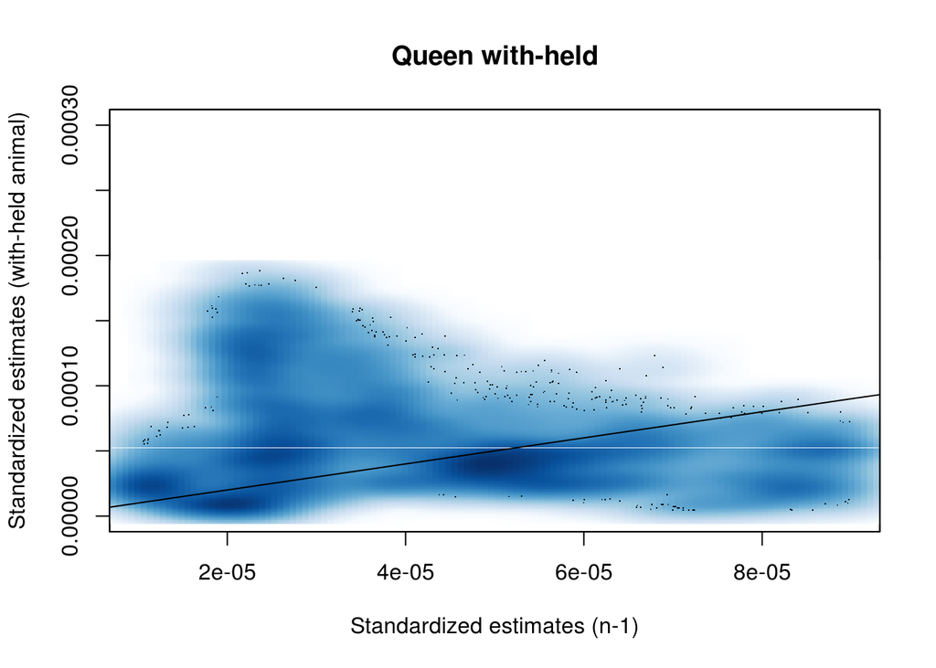

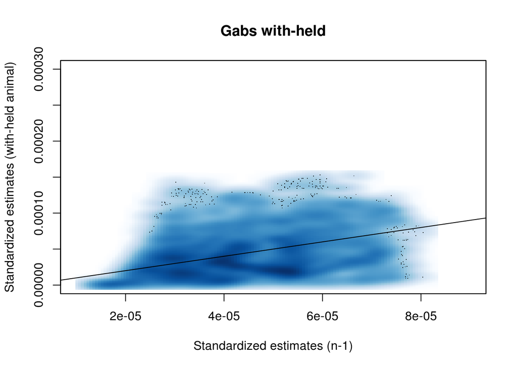

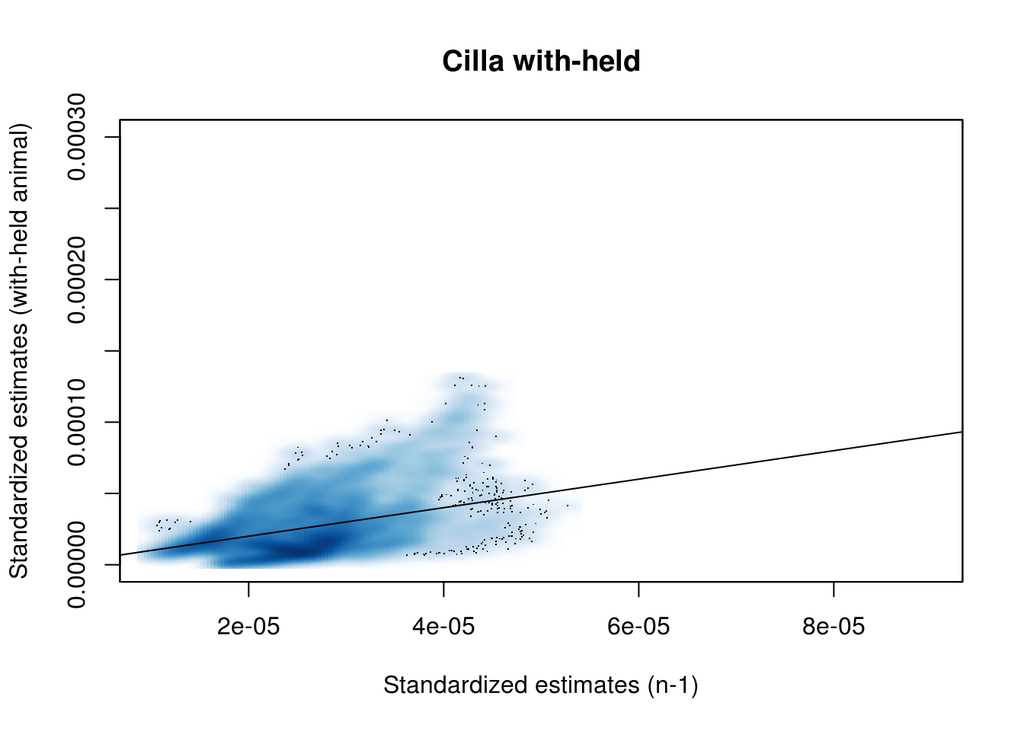

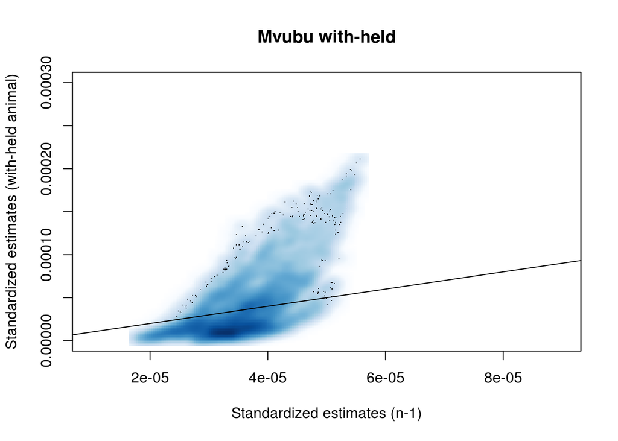

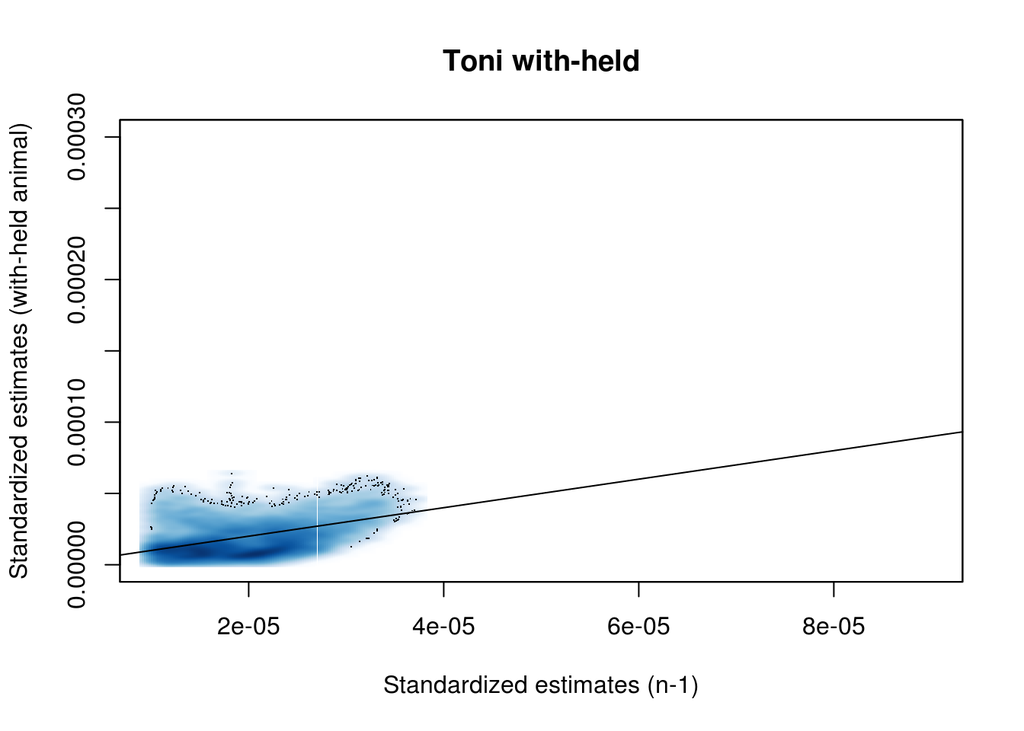

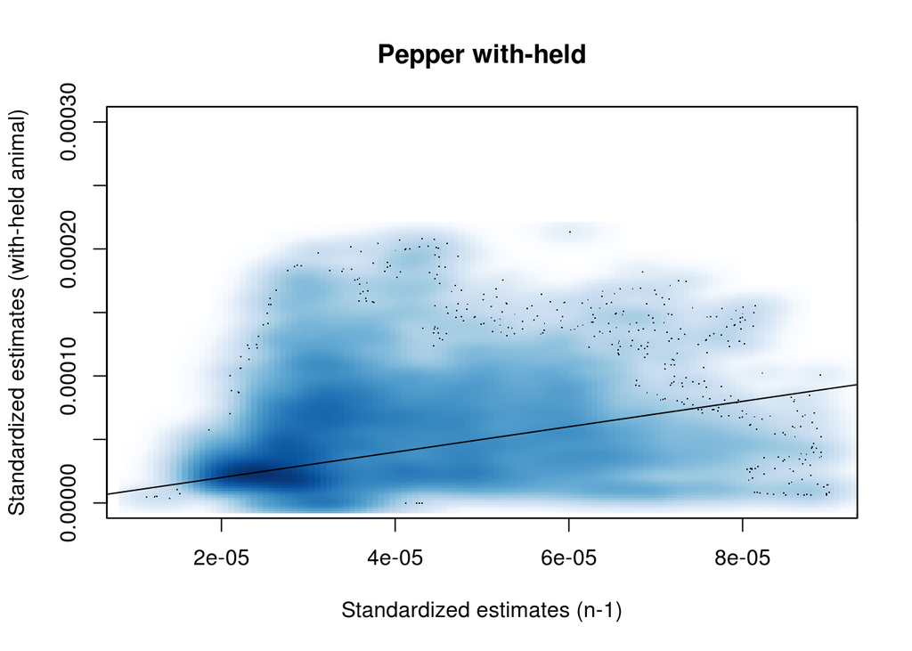

```r
# Plot function for LOO fits
plotLOO(out)
```